# Mann-Kendall-Sneyers Test Report

The **MKS Test** is used to identify the beginning of a trend in a time series:

- Null Hypothesis: There are no change points in the time series.
- Alternative Hypothesis: There are *one or more* change points in the time series.

Define $\mathbb{I}(y_{i} > y_{j})$ to be $1$ if $y_{i} > y_{j}$ and $0$ otherwise.

Given a time series $y_{1}, \dots, y_{n}$, we compute the following test statistic:

$$\begin{equation}
S_{t} = \sum_{i=i}^{t} \sum_{j=1}^{i-1} \mathbb{I}(y_{i} > y_{j})
\end{equation}$$

Then, we compute the the **Progressive Series** $UF_{t}$:

$$UF_{t} = \frac{S_{t} - \mathbb{E}[S_{t}]}{\sqrt{\text{Var}\,(S_{t})}}$$

Next, we reverse the time series to create a new time series $y'$ such that $y'_{i} = y_{n+1-i}$. Then, we use formula (1) to compute $S_{t}'$ for $y'$ and reverse $S_{t}'$ to get $S_{t}''$ .

The **Regressive Series** $UB_{t}$ is defined as follows:

$$UB_{t} = \frac{S_{t}'' -
\mathbb{E}[S_{t}'']}{\sqrt{\text{Var}\,(S_{t}'')}}$$

For both the progressive and regressive series, the expectation and variance is as follows:

$$\mathbb{E}[S_{t}] = \mathbb{E}[S_{t}'']= \frac{t(t-1)}{4}
\\[5pt]
\text{Var}(S_{t}) = \text{Var}(S_{t}'') =
\frac{t(t-1)(2t+5)}{72}$$

Finally, we plot $UF_{t}$ and $UB_{t}$ with confidence bounds at $\pm z_{1 - (\alpha/2)}$, where $\alpha$ is the chosen significance level. A crossing point between $UF_{t}$ and $UB_{t}$ that lies outside the confidence bounds indicates the start of the trend.

## Results

### Code

```r
# Mann-Kendall-Sneyers test for detecting the beginning of a trend
#  - ams: A vector of annual maximum streamflow data with no NA values
#  - year: A numeric vector of years corresponding to ams with no NA values
#  - alpha: The significance level as a floating point number
mks_test <- function(ams, year, alpha = 0.05) {

    # Compute number of elements such that ams[i] > ams[j] for all j < i < t for all t.
    s_statistic <- function(vt, ams) {

        # Computes the number of elements such that ams[i] > ams[j] for j < i (given i).
        sum_i <- function(i) sum(ams[i] > ams[1:i-1])

        # Applies the sum_i function to a vector values.
        n_i <- sapply(vt, sum_i)

        # Compute cumulative sum of n_i values to get the S-statistic for all t.
        cumsum(n_i)
    }

    # Compute the forward and backwards s-statistics
    idx <- 1:length(ams)
    s_prog_non_normal <- s_statistic(idx, ams)
    s_regr_non_normal <- s_statistic(idx, rev(ams))

    # Get the variance and expectation of the S-statistics
    s_expectation = idx * (idx - 1) / 4
    s_variance = (idx * (idx - 1) * ((2 * idx) + 5)) / 72

    # Prevent a division by zero error at idx = 1
    s_variance[s_variance == 0] <- 1

    # Compute the normalized progressive and regressive s-statistics
    s_prog <- (s_prog_non_normal - s_expectation) / sqrt(s_variance)
    s_regr <- rev((s_regr_non_normal - s_expectation) / sqrt(s_variance))

    # Compute confidence bounds for the normalized s-statistics
    bound <- qnorm(1 - (alpha / 2))

    # Find all crossings between progressive/regressive series
    s_sign <- sign(s_prog - s_regr)
    cross <- which(s_sign[-1] != s_sign[-length(s_sign)])

    # Compute the location of each crossing using linear interpolation
    get_crossing_location <- function(i) {

        # Fit linear models
        fit_prog <- lm(s_prog[i:(i + 1)] ~ year[i:(i + 1)])
        fit_regr <- lm(s_regr[i:(i + 1)] ~ year[i:(i + 1)])

        # Get the slope and y-intercept of each line
        b_prog <- coef(fit_prog)[1]
        b_regr <- coef(fit_regr)[1]
        m_prog <- coef(fit_prog)[2]
        m_regr <- coef(fit_regr)[2]

        # Compute and return y-coordinate of the intersection point
        x_inter = (b_regr - b_prog) / (m_prog - m_regr)
        y_inter = (m_prog * x_inter) + b_prog
        as.numeric(y_inter)

    }

    # Create a dataframe of all crossings
    crossing_df <- data.frame(
        cross = cross,
        year = year[cross],
        statistic = sapply(cross, get_crossing_location),
        max = ams[cross]
    )

    # Compute the p-value of the test (i.e. the maximum crossing location)
    p_value <- ifelse(
        nrow(crossing_df) > 0,
        2 * (1 - pnorm(max(abs(crossing_df$statistic)))),
        1
    )

    # Determine the outcome
    outcome <- ifelse(p_value <= alpha, "reject", "fail to reject")

    # Return a list of values results from the test
    mget(c("s_prog", "s_regr", "bound", "crossing_df", "p_value", "outcome"))

}
```

## Statistics

- P-value: 0.237
- Significance level: 0.05

Given the test statistic and p-value, we *fail to reject* the null hypothesis.

There are no statistically significant change points.

## Figure

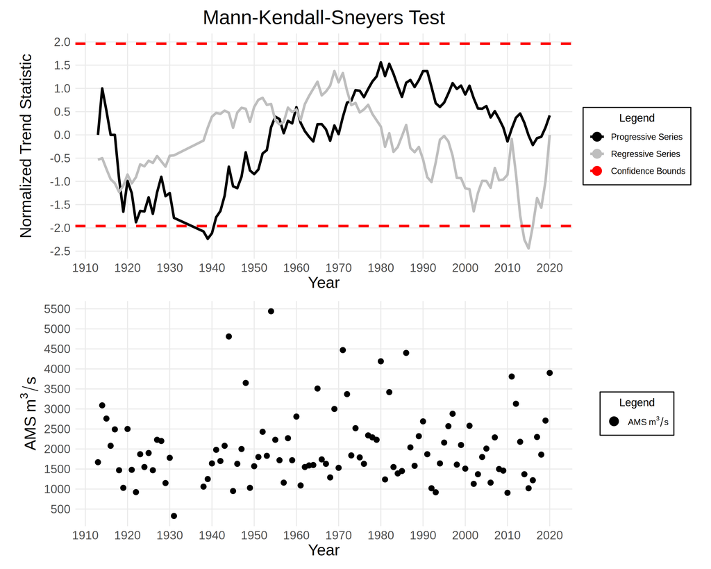

```r
library(ggplot2)
library(patchwork)

# Source the plot theme (working directory is /source)
source("stats/plot-theme.R")


# Plot the results of the MKS test
mks_plot <- function(df_clean, result, show_trend) {

    # Load the values of result into the environment
    list2env(result, env = environment())

    # Create a dataframe for the bounds
    bound_df <- data.frame(y = c(-bound, bound))

    # Add the test statistics to df_clean
    df_clean$s_prog = s_prog
    df_clean$s_regr = s_regr

    # Subset crossing_df on the statistically significant crossings
    crossing_df = crossing_df[which(abs(crossing_df$statistic) > abs(bound)), ]

    # Define labels for the plot
    ut_label <- "Normalized Trend Statistic"
    flow_label <- expression(AMS ~ m^3/s)
    series_labels <- c("Progressive Series", "Regressive Series")

    # Plot the normalized trend statistics and confidence bands
    p1 <- ggplot(df_clean, aes(x = year)) +
        geom_line(aes(color = "black", y = s_prog), linewidth = 1.2) +
        geom_line(aes(color = "gray",  y = s_regr), linewidth = 1.2) +
        geom_hline(
            data = bound_df,
            aes(yintercept = y, color = "red"),
            linewidth = 1.2,
            linetype = "dashed",
        ) +
        geom_point(
            data = crossing_df,
            aes(y = statistic, color = "blue"),
            size = 4
        ) +
        labs(
            title = "Mann-Kendall-Sneyers Test",
            x = "Year",
            y = ut_label,
            color = "Legend"
        ) +
        scale_color_manual(
            values = c("black" = "black","gray" = "gray","blue" = "blue","red" = "red"),
            breaks = c("black", "gray", "red", "blue"),
            labels = c(series_labels, "Confidence Bounds", "Potential Trend Change")
        )

    # Plot the change points on the original dataset
    p2 <- ggplot(df_clean, aes(x = year, y = max)) +
        geom_point(aes(color = "black"), size = 2.25) +
        (if (show_trend) geom_line(color = "black", linewidth = 1.1) else NULL) +
        geom_point(data = crossing_df, aes(color = "blue"), size = 4) +
        labs(x = "Year", y = flow_label, color = "Legend") +
        scale_color_manual(
            values = c("black" = "black", "blue" = "blue"),
            breaks = c("black", "blue"),
            labels = c(flow_label, "Potential Change Point")
        )

    # Stack plots on top of each other and return
    add_theme(p1) / add_theme(p2)

}
```